# Black And Yellow Rockfish

*Sebastes chrysomelas*

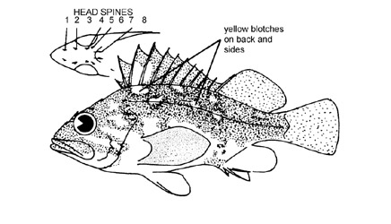

**Body color:** Black, w/ irregular clear yellow blotches on back, lateral line, and lower sides; clear areas tend to run together on lower sides; yellow patch on membranes between anterior dorsal spines.

**Peritoneum color:** light **Shape between eyes:** concave

**Counts:** D:XIII,12-14, Ar:5-7, P1:17-18, GR:25-30, LLp:35-46, LLs:?-?, V:26

**Occurence:** Northern California - Baja California

**Depth:** 37 meters **Size:** 38 cm **Species code:** 30155

Back to Group

**Corrections:** If you see mistakes or want to suggest changes, please create an [issue](https://github.com/zoyafuso-NOAA/RACE_Survey_App/issues) on the source repository or

*reach out to Liz Dawson (Liz.Dawson AT noaa.gov).*